# Milestone Report for Data Science Capstone

Tianxing Li

July 25, 2015

This report gives exploratory analysis on the given data. The data is from a corpus called HC Corpora (www.corpora.heliohost.org), including files named LOCALE.blogs.txt where LOCALE is the each of the four locales en_US, de_DE, ru_RU and fi_FI. This report focusses mainly on the English data: `en_US.twitter.txt`, `en_US.blogs.txt` and `en_US.news.txt`.

## 1. Load the data

First of all, load the data into R.

```r
if(!dir.exists("./data")) {
  dir.create("./data")
  download.file("https://d396qusza40orc.cloudfront.net/dsscapstone/dataset/Coursera-SwiftKey.zip",
                "./data/Coursera-SwiftKey.zip", method="curl")
  unzip("./data/Coursera-SwiftKey.zip", exdir = "./data")
}

en_US_twitter <- readLines("./data/final/en_US/en_US.twitter.txt", skipNul=T, encoding="UTF-8")
en_US_blogs <- readLines("./data/final/en_US/en_US.blogs.txt", skipNul=T, encoding="UTF-8")
en_US_news  <- readLines("./data/final/en_US/en_US.news.txt", skipNul=T, encoding="UTF-8")
```

Then we can take a quick look at the raw data.

```r
library(knitr)
twitter_line_cnt <- length(en_US_twitter)
twitter_word_cnt <- sum(sapply(strsplit(en_US_twitter, "\\s+"), length))
blogs_line_cnt <- length(en_US_blogs)
blogs_word_cnt <- sum(sapply(strsplit(en_US_blogs, "\\s+"), length))
news_line_cnt <- length(en_US_news)
news_word_cnt <- sum(sapply(strsplit(en_US_news, "\\s+"), length))

line_count <- c(twitter_line_cnt, blogs_line_cnt, news_line_cnt)
word_count <- c(twitter_word_cnt, blogs_word_cnt, news_word_cnt)

info = data.frame(row.names=c("en_US.twitter.txt", "en_US.blogs.txt", "en_US.news.txt"),
                  LineCount=line_count,
                  WordCount=word_count,
                  WordLineRate=word_count/line_count)

kable(info)
```

|  | LineCount | WordCount | WordLineRate |
| --- | --- | --- | --- |
| en_US.twitter.txt | 2360148 | 30373583 | 12.86936 |
| en_US.blogs.txt | 899288 | 37334131 | 41.51521 |
| en_US.news.txt | 1010242 | 34372530 | 34.02406 |

## 2. Clean the data

The raw data is very big, we need to sample the three raw data. Since the reason above, we should take more news data and less twitter data.

```r
TOTAL_ITEM = 10000
PROPORTION = c(0.2, 0.3, 0.5)
set.seed(10086)

sampled_twitter <- en_US_twitter[sample(1:twitter_line_cnt, TOTAL_ITEM*PROPORTION[1])]
rm(en_US_twitter)
sampled_blogs <- en_US_blogs[sample(1:blogs_line_cnt, TOTAL_ITEM*PROPORTION[2])]
rm(en_US_blogs)
sampled_news <- en_US_news[sample(1:news_line_cnt, TOTAL_ITEM*PROPORTION[3])]
rm(en_US_news)

sampled_data <- c(sampled_twitter, sampled_blogs, sampled_news)
```

The sampled data is still raw. It contains punctuation, hashtag, white spaces, and mixed with upper and lower cases. We need to clean the data before perform any further analysis.

```r
library("tm")
sampled_data_corpus <- Corpus(VectorSource(sampled_data))
sampled_data_corpus <- tm_map(sampled_data_corpus, PlainTextDocument)
sampled_data_corpus <- tm_map(sampled_data_corpus, stripWhitespace)
sampled_data_corpus <- tm_map(sampled_data_corpus, removePunctuation)
sampled_data_corpus <- tm_map(sampled_data_corpus, removeNumbers)
```

## 3. Show the frequency of words

To show the frequency summary of words, first we need to perform tokenization.

```r
library(RWeka)
library(slam)

options(mc.cores=1)
u_gram_tokenizer <- function(x) NGramTokenizer(x, Weka_control(min = 1, max = 1))
b_gram_tokenizer <- function(x) NGramTokenizer(x, Weka_control(min = 2, max = 2))
t_gram_tokenizer <- function(x) NGramTokenizer(x, Weka_control(min = 3, max = 3))

u_tdm <- TermDocumentMatrix(sampled_data_corpus, control = list(tokenize = u_gram_tokenizer))
b_tdm <- TermDocumentMatrix(sampled_data_corpus, control = list(tokenize = b_gram_tokenizer))
t_tdm <- TermDocumentMatrix(sampled_data_corpus, control = list(tokenize = t_gram_tokenizer))

get_top_freq <- function(tdm)  {
  tdm_up <- rollup(tdm, 2, na.rm=TRUE, FUN = sum)
  inspect_tdm <- inspect(tdm_up)
  freq_mat <- data.frame(ST = rownames(inspect_tdm), Freq = rowSums(inspect_tdm))
  sort <- freq_mat[with(freq_mat, order(-Freq)), ]
  top <- sort[1:20, ]
  return(top)
}

u_top <- get_top_freq(u_tdm)
b_top <- get_top_freq(b_tdm)
t_top <- get_top_freq(t_tdm)
```

Then we can plot the most frequently used words.

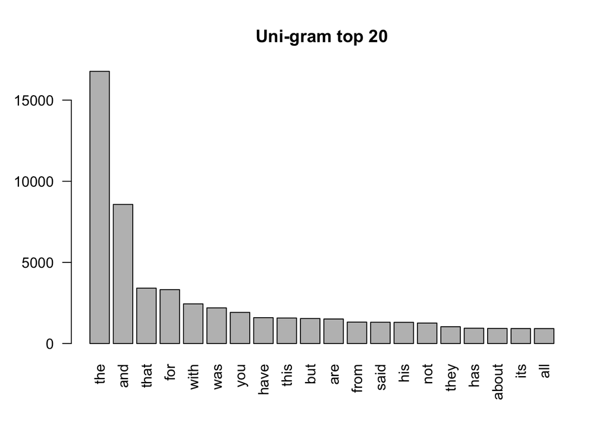

```r
barplot(u_top$Freq, names=u_top$ST, las=2, main="Uni-gram top 20")
```

The most used words from the uni-gram are determiners, conjunctions and prepositions, like “the”, “and”, “that” and “for”.

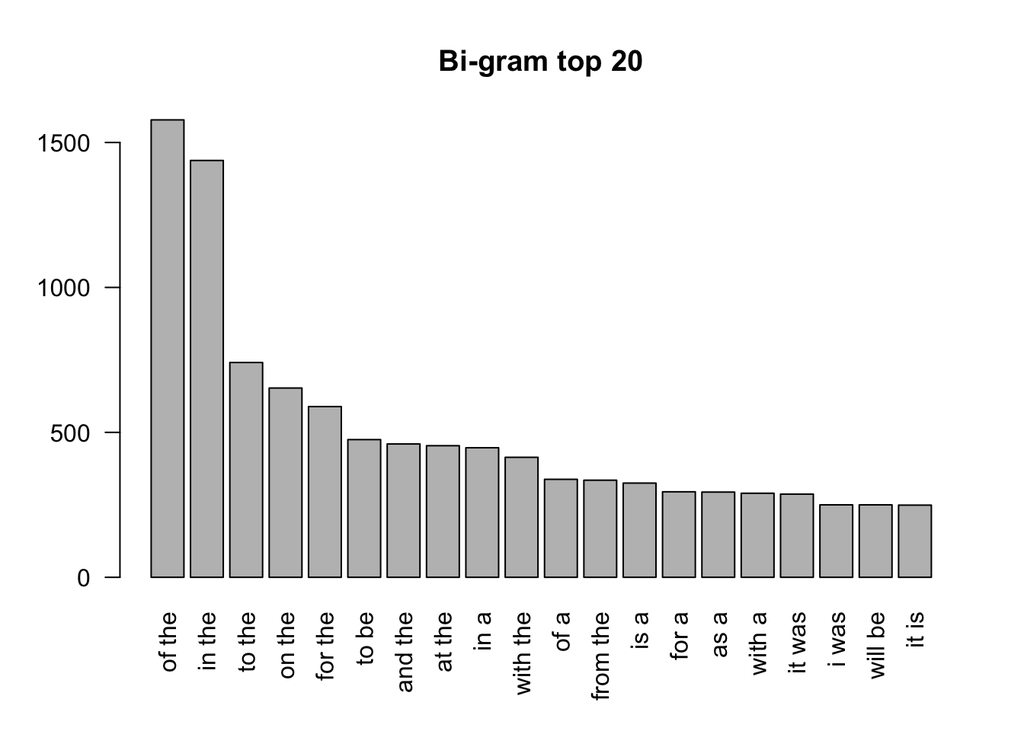

```r
barplot(b_top$Freq, names=b_top$ST, las=2, main="Bi-gram top 20")
```

The most used phrases from the bi-gram are the phrases with determiners, conjunctions and prepositions. The phrases with the word “the” take 9 position out of the top 20.

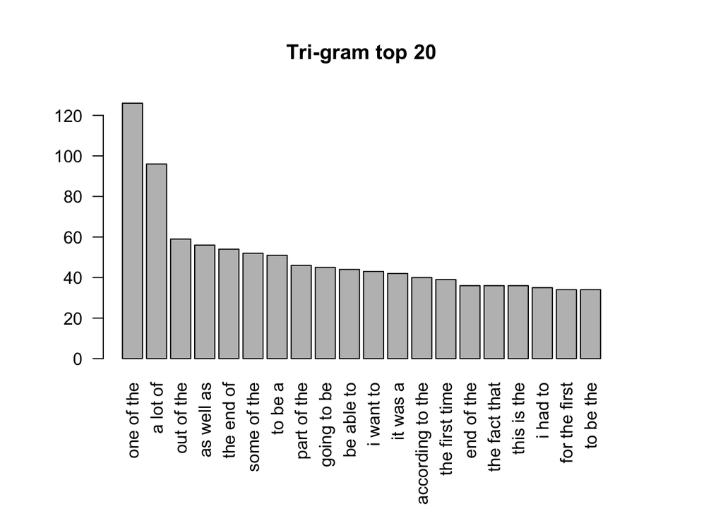

```r
.pardefault <- par()
par(mai=c(1.5, 1, 1, 1))
barplot(t_top$Freq, names=t_top$ST, las=2, main="Tri-gram top 20")
```

```r
par(.pardefault)
```

The most used phrases from the tri-gram also contains a lot “the” phrases, as well as some useful expressions like “a lot of” and “as well as”.

## 4. Plans

Now that the data is sampled and cleaned, it can be used to trained the model and build the prediction alogrithm. The model and the prediction alogrithm can be used to power the Shiny app.

The app should include a text box for input. With each word input, the alogrithm predicts the possible next words and the app displays some of the most likely words in the list below.